# Conditional density estimation using `haldensify`

## Overview

This coding tutorial uses the `haldensify` package to estimate a conditional density with the highly adaptive lasso (HAL).

By the end of the tutorial, you will be able to:

- simulate data from a known conditional distribution;
- fit a cross-validated HAL conditional density estimator;
- interpret the empirical-risk path used to select the Lasso penalty;
- evaluate the fitted density on a structured grid;
- and compare the estimated and true densities with both line plots and interactive surfaces.

## 1. Setup

We first load the packages we need for this tutorial. `haldensify` fits the conditional density; `dplyr` and `tidyr` help us inspect and reshape results; `ggplot2` creates static diagnostic plots; and `plotly` creates rotatable three-dimensional surfaces for better interactive visualizations.

```r
# load required packages
library(haldensify)
library(dplyr)
library(tidyr)
library(ggplot2)
library(plotly)
```

If needed, install the packages before proceeding the tutorial.

```r
install.packages(c("haldensify", "dplyr", "tidyr", "ggplot2", "plotly"))
```

We set a seed so that the simulated data (and therefore every fitted result in the tutorial) can be reproduced. The helper file `sim_data.R` lives in the same directory as this document.

```r
set.seed(75681)
source("sim_data.R")
```

## 2. Understand the data-generating process

Let $W=(W_1,W_2)$, where $W_1,W_2 \overset{\mathrm{iid}}{\sim} N(0,1).$ Conditional on $W$, the continuous variable $A$ follows a normal distribution: $A\mid W=w \sim N\!\left(\mu_A(w),\sigma_A^2(w)\right),$ with $\mu_A(w)=1+0.3w_1-1.5w_2$ and $\sigma_A(w)=2+0.3|w_1|.$

Thus, both the location and spread of $A\mid W$ change with the covariates. The true conditional density is

$$g_0(a\mid w)
=\frac{1}{\sigma_A(w)}
\phi\!\left(\frac{a-\mu_A(w)}{\sigma_A(w)}\right),$$

where $\phi$ is the standard normal density.

### Simulate the observed data

```r
n <- 500
data <- sim_data(n)
```

Here, we check the structure and basic marginal summaries.

```r
dplyr::glimpse(data)
```

```
Rows: 500
Columns: 3
$ W1 <dbl> 0.77509790, -1.14246705, 1.63483829, -1.18666555, -1.73437211, 0.98…
$ W2 <dbl> 1.137207387, 1.127008356, 0.120203122, -0.848469904, 1.876121380, -…
$ A  <dbl> -1.3576912, -2.1534798, 3.9102773, 3.3953566, 0.2698453, 4.1968480,…
```

```r
summary(data)
```

```
       W1                 W2                   A
 Min.   :-2.51634   Min.   :-3.0236447   Min.   :-8.2886
 1st Qu.:-0.68487   1st Qu.:-0.6892753   1st Qu.:-1.0388
 Median :-0.07930   Median : 0.0002331   Median : 0.7100
 Mean   :-0.03675   Mean   : 0.0276948   Mean   : 0.8603
 3rd Qu.: 0.60739   3rd Qu.: 0.7366232   3rd Qu.: 2.6183
 Max.   : 3.17026   Max.   : 3.3209255   Max.   : 9.6683
```

The next plot shows an exploratory view of the data. The black smooth curve shows how the average of $A$ varies with $W_1$, while color reveals the stronger negative shift associated with $W_2$.

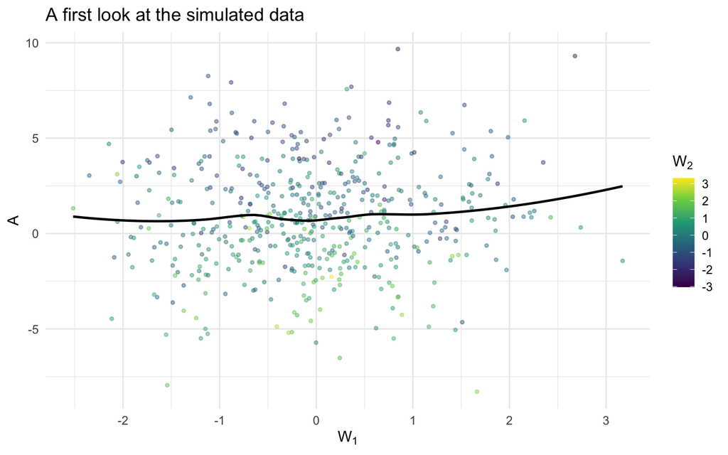

Figure 1: Observed values of A against W1, colored by W2. The black curve is a descriptive smooth through the simulated observations.

```r
ggplot(data, aes(x = W1, y = A, color = W2)) +
  geom_point(alpha = 0.45, size = 1) +
  geom_smooth(
    aes(group = 1),
    method = "loess",
    se = FALSE,
    color = "black",
    linewidth = 0.9
  ) +
  scale_color_viridis_c() +
  labs(
    x = expression(W[1]),
    y = "A",
    color = expression(W[2]),
    title = "A first look at the simulated data"
  ) +
  theme_minimal(base_size = 12)
```

## 3. Fit the HAL conditional density estimator

At a high level, `haldensify` divides the observed support of $A$ into ordered bins, represents the density through a sequence of conditional hazards, fits those hazards using HAL, and maps the estimated hazards back to a density. Its cross-validation procedure selects tuning parameters by minimizing a density log-likelihood loss.

The fitting call has three key inputs:

- `A = data$A` supplies the continuous variable whose density we want;
- `W = data$W` supplies the conditioning variables; and
- `lambda_seq` supplies candidate Lasso penalties.

```r
haldensify_fit <- haldensify(A = data$A,
                             W = data[, c("W1", "W2")],
                             lambda_seq = exp(seq(-5, -15, length = 50)))
```

The 50 candidate penalties decrease from $\exp(-5)$ to $\exp(-15)$ on a logarithmic scale. Larger values impose more shrinkage; smaller values allow a more flexible HAL fit. The package uses cross-validation to choose among these candidates.

**NoteComputational note**

This is the most expensive step in the tutorial. It fits a sequence of HAL models inside cross-validation, so runtime depends on the sample size, the number of candidate penalties, and the machine. For quicker experimentation, start with a smaller `n` or a shorter `lambda_seq`.

We can inspect the selected penalty and its position in the candidate path.

```r
lambda_summary <- data.frame(
  quantity = c(
    "Largest candidate lambda",
    "Smallest candidate lambda",
    "Cross-validated lambda",
    "Selected path index"
  ),
  value = c(
    formatC(
      max(haldensify_fit$cv_tuning_results$lambda_seq),
      format = "e", digits = 3
    ),
    formatC(
      min(haldensify_fit$cv_tuning_results$lambda_seq),
      format = "e", digits = 3
    ),
    formatC(
      haldensify_fit$cv_tuning_results$lambda_loss_min,
      format = "e", digits = 3
    ),
    sprintf(
      "%d of %d",
      haldensify_fit$cv_tuning_results$lambda_loss_min_idx,
      length(haldensify_fit$cv_tuning_results$lambda_seq)
    )
  )
)

lambda_summary
```

```
                   quantity     value
1  Largest candidate lambda 6.738e-03
2 Smallest candidate lambda 3.059e-07
3    Cross-validated lambda 4.746e-04
4       Selected path index  14 of 50
```

### Diagnose the risk path

The package’s `plot()` method displays empirical risk along the regularization path. Its horizontal axis is $-\log(\lambda)$, so moving to the right means using a smaller penalty and a more flexible model. The dotted vertical line marks the penalty with minimum cross-validated risk.

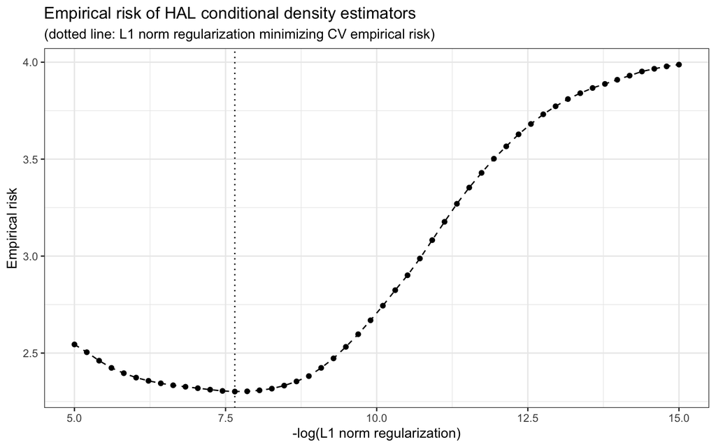

Figure 2: Empirical risk over the HAL regularization path. The dotted line marks the cross-validated choice of lambda.

```r
# empirical risk vs. lambda
risk_vs_lambda <- plot(haldensify_fit)
risk_vs_lambda
```

## 4. Construct an evaluation grid

The fitted object estimates a function of three arguments, $g(a\mid w_1,w_2)$. A single three-dimensional surface can display only two input axes plus density height, so we hold $W_2=0$ and vary $A$ and $W_1$:

- 20 values of $W_1$ from $-2$ to $2$;
- one fixed value, $W_2=0$; and
- 30 values of $A$ from $-2$ to $6$.

The Cartesian product contains $20\times 1\times 30=600$ evaluation points.

```r
# compute true conditional densities over a grid
W1_vals <- seq(-2, 2, length.out = 20)
W2_fixed <- 0
A_vals <- seq(-2, 6, length.out = 30)
grid <- expand.grid(W1 = W1_vals,
                    W2 = W2_fixed,
                    A = A_vals)
```

Inspecting the grid makes its ordering explicit.

```r
dim(grid)
```

```
[1] 600   3
```

```r
head(grid, 8)
```

```
          W1 W2  A
1 -2.0000000  0 -2
2 -1.7894737  0 -2
3 -1.5789474  0 -2
4 -1.3684211  0 -2
5 -1.1578947  0 -2
6 -0.9473684  0 -2
7 -0.7368421  0 -2
8 -0.5263158  0 -2
```

```r
tail(grid, 8)
```

```
           W1 W2 A
593 0.5263158  0 6
594 0.7368421  0 6
595 0.9473684  0 6
596 1.1578947  0 6
597 1.3684211  0 6
598 1.5789474  0 6
599 1.7894737  0 6
600 2.0000000  0 6
```

**ImportantThis surface is a slice**

The plots below describe $g(a\mid W_1=w_1,W_2=0)$, not the entire conditional density over every value of $W_2$. Changing `W2_fixed` produces a different slice.

## 5. Evaluate the truth and the fitted density

The simulation helper, with no `grid`, generates random observations. With a `grid`, it evaluates the known normal density at each row and returns those density values in its `A` column. We save them as `true_dens`.

```r
grid$true_dens <- sim_data(n, grid = grid)$A
```

Next, we ask the fitted model for one density estimate per grid row. `new_A` and `new_W` must describe matching evaluation points and therefore must have the same number of rows.

```r
grid$pred_dens <- predict(haldensify_fit,
                          new_A = grid$A,
                          new_W = grid[, c("W1", "W2")])
```

By default, `predict.haldensify()` uses the cross-validated penalty.

### Quantify agreement on this grid

Let’s first first look at some numerical summaries.

```r
density_error <- grid |>
  summarise(
    MAE = mean(abs(pred_dens - true_dens)),
    RMSE = sqrt(mean((pred_dens - true_dens)^2)),
    correlation = cor(pred_dens, true_dens)
  )

density_error
```

```
         MAE       RMSE correlation
1 0.01819903 0.02347834   0.9131209
```

### Compare a few one-dimensional slices

We select three representative values of $W_1$ and overlay the estimated and true density curves.

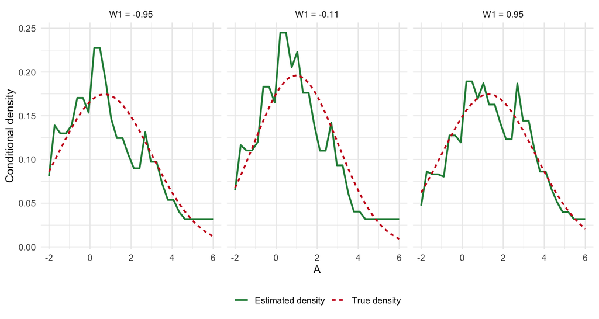

Figure 3: Estimated and true conditional density curves at three values of W1, with W2 fixed at zero.

```r
slice_W1_vals <- W1_vals[c(6, 10, 15)]

grid |>
  filter(W1 %in% slice_W1_vals) |>
  select(A, W1, true_dens, pred_dens) |>
  pivot_longer(
    cols = c(true_dens, pred_dens),
    names_to = "curve",
    values_to = "density"
  ) |>
  mutate(
    curve = recode(
      curve,
      true_dens = "True density",
      pred_dens = "Estimated density"
    ),
    W1_slice = factor(
      sprintf("W1 = %.2f", W1),
      levels = sprintf("W1 = %.2f", slice_W1_vals)
    )
  ) |>
  ggplot(aes(x = A, y = density, color = curve, linetype = curve)) +
  geom_line(linewidth = 0.9) +
  facet_wrap(vars(W1_slice), nrow = 1) +
  scale_color_manual(values = c(
    "Estimated density" = "#238b45",
    "True density" = "#cb181d"
  )) +
  labs(
    x = "A",
    y = "Conditional density",
    color = NULL,
    linetype = NULL
  ) +
  theme_minimal(base_size = 12) +
  theme(legend.position = "bottom")
```

Because $W_2=0$ in these slices, the true mean is $1+0.3W_1$. As $W_1$ increases, the center of the density moves to the right. The true standard deviation is $2+0.3|W_1|$, so the density is also somewhat wider and flatter when $W_1$ is farther from zero.

## 6. Build the interactive density surfaces

`plotly::add_surface()` expects a matrix whose rows correspond to the values on the `y` axis and whose columns correspond to the values on the `x` axis. Our plots use $W_1$ on `y` and $A$ on `x`, so each density matrix must have `length(W1_vals)` rows and `length(A_vals)` columns.

This ordering also matches the vector produced from our grid.

```r
pred_dens_mat <- matrix(grid$pred_dens,
                        nrow = length(W1_vals),
                        ncol = length(A_vals),
                        byrow = FALSE)
true_dens_mat <- matrix(grid$true_dens,
                        nrow = length(W1_vals),
                        ncol = length(A_vals),
                        byrow = FALSE)

stopifnot(
  identical(dim(pred_dens_mat), c(length(W1_vals), length(A_vals))),
  identical(dim(true_dens_mat), c(length(W1_vals), length(A_vals)))
)
```

The estimated density is green and the true density is red. Both use the same axes, camera angle, and vertical range.

```r
plt_pred <- plot_ly(x = A_vals, y = W1_vals, z = pred_dens_mat,
        colorscale = "Greens") %>%
  add_surface() %>%
  layout(title = list(text = "Estimated Conditional Density",
                      font = list(size = 18, color = "black"),
                      yref = "container",
                      y = 0.98),
         scene = list(xaxis = list(title = "A", titlefont = list(size = 14)),
                      yaxis = list(title = "W1", titlefont = list(size = 14)),
                      zaxis = list(title = "Density", titlefont = list(size = 14), range = c(0, 0.2)),
                      camera = list(eye = list(x = 1.5, y = 1.5, z = 1))),
         legend = list(x = 0.8, y = 1, font = list(size = 12)))

plt_true <- plot_ly(x = A_vals, y = W1_vals, z = true_dens_mat,
        colorscale = "Reds") %>%
  add_surface() %>%
  layout(title = list(text = "True Conditional Density",
                      font = list(size = 18, color = "black"),
                      yref = "container",
                      y = 0.98),
         scene = list(xaxis = list(title = "A", titlefont = list(size = 14)),
                      yaxis = list(title = "W1", titlefont = list(size = 14)),
                      zaxis = list(title = "Density", titlefont = list(size = 14), range = c(0, 0.2)),
                      camera = list(eye = list(x = 1.5, y = 1.5, z = 1))),
         legend = list(x = 0.8, y = 1, font = list(size = 12)))
```

### Estimated conditional density

Drag to rotate the surface, scroll to zoom, and hover to inspect individual values.

```r
plt_pred
```

[interactive chart not shown]

Figure 4: HAL estimate of the conditional density of A given W1, evaluated with W2 fixed at zero.

### True conditional density

```r
plt_true
```

[interactive chart not shown]

Figure 5: True conditional density of A given W1, evaluated with W2 fixed at zero.

## 7. Adapt the workflow to your own data

For an applied analysis, replace `data$A` with a numeric continuous variable and replace `data$W` with a data frame or matrix containing the conditioning variables. The template is:

```r
fit <- haldensify(
  A = observed_A,
  W = observed_W,
  lambda_seq = exp(seq(-0.1, -10, length = 300))
)

density_hat <- predict(
  fit,
  new_A = evaluation_A,
  new_W = evaluation_W
)
```